```python
#loading the Required Libraries.
#NumPy is a Python Library used to perform wide variety of Mathematical Operations on Arrays.
import numpy as np
#Pandas is a Python Library used to analyze big data and make Conclusions based on Stastical Theories.
import pandas as pd
#matplotlib.pyplot contains functions that make matplotlib work like MATLAB and
#each pyplot fuction makes some changes in the figure.
from matplotlib import pyplot as plt
import seaborn as sns
```

# Importing the Dataset.

```python
#Loading the Dataset.
Data=pd.read_csv("C:\\Users\\Admin\\Desktop\\Madhu\\Anaconda-Jupyter\\IPL 2008-2019 Jupyter Project\\Raw Data.csv")
```

```python
#To get First 5 Rows of Dataset.
Data.head()
```

|  | ID NO | Season | City | Date | Team 1 | Team 2 | Toss_Winner | Toss_Decision | Result | DL_Applied | Winner | Win_by_Runs | Win_by_Wickets | Player_of_Match | Venue | Umpire 1 | Umpire 2 | Umpire 3 |
| --- | --- | --- | --- | --- | --- | --- | --- | --- | --- | --- | --- | --- | --- | --- | --- | --- | --- | --- |
| 0 | 1 | 2017 | Hyderabad | 4/5/2017 | Sunrisers Hyderabad | Royal Challengers Bangalore | Royal Challengers Bangalore | To Field | Normal | 0 | Sunrisers Hyderabad | 35 | 0 | Yuvraj Singh | Rajiv Gandhi International Stadium, Uppal | AY Dandekar | NJ Llong | Not Avaliable |
| 1 | 2 | 2017 | Pune | 4/6/2017 | Mumbai Indians | Rising Pune Supergiant | Rising Pune Supergiant | To Field | Normal | 0 | Rising Pune Supergiant | 0 | 7 | SPD Smith | Maharashtra Cricket Association Stadium | A Nand Kishore | S Ravi | Not Avaliable |
| 2 | 3 | 2017 | Rajkot | 4/7/2017 | Gujarat Lions | Kolkata Knight Riders | Kolkata Knight Riders | To Field | Normal | 0 | Kolkata Knight Riders | 0 | 10 | CA Lynn | Saurashtra Cricket Association Stadium | Nitin Menon | CK Nandan | Not Avaliable |
| 3 | 4 | 2017 | Indore | 4/8/2017 | Rising Pune Supergiant | Kings XI Punjab | Kings XI Punjab | To Field | Normal | 0 | Kings XI Punjab | 0 | 6 | GJ Maxwell | Holkar Cricket Stadium | AK Chaudhary | C Shamshuddin | Not Avaliable |
| 4 | 5 | 2017 | Bangalore | 4/8/2017 | Royal Challengers Bangalore | Delhi Daredevils | Royal Challengers Bangalore | To Bat | Normal | 0 | Royal Challengers Bangalore | 15 | 0 | KM Jadhav | M Chinnaswamy Stadium | Not Avaliable | Not Avaliable | Not Avaliable |

```python
#To get Last 5 Rows of Dataset.
Data.tail()
```

|  | ID NO | Season | City | Date | Team 1 | Team 2 | Toss_Winner | Toss_Decision | Result | DL_Applied | Winner | Win_by_Runs | Win_by_Wickets | Player_of_Match | Venue | Umpire 1 | Umpire 2 | Umpire 3 |
| --- | --- | --- | --- | --- | --- | --- | --- | --- | --- | --- | --- | --- | --- | --- | --- | --- | --- | --- |
| 751 | 11347 | 2019 | Mumbai | 5/5/2019 | Kolkata Knight Riders | Mumbai Indians | Mumbai Indians | To Field | Normal | 0 | Mumbai Indians | 0 | 9 | HH Pandya | Wankhede Stadium | Nanda Kishore | O Nandan | S Ravi |
| 752 | 11412 | 2019 | Chennai | 7/5/2019 | Chennai Super Kings | Mumbai Indians | Chennai Super Kings | To Bat | Normal | 0 | Mumbai Indians | 0 | 6 | AS Yadav | M. A. Chidambaram Stadium | Nigel Llong | Nitin Menon | Ian Gould |
| 753 | 11413 | 2019 | Visakhapatnam | 8/5/2019 | Sunrisers Hyderabad | Delhi Capitals | Delhi Capitals | To Field | Normal | 0 | Delhi Capitals | 0 | 2 | RR Pant | ACA-VDCA Stadium | Not Avaliable | Not Avaliable | Not Avaliable |
| 754 | 11414 | 2019 | Visakhapatnam | 10/5/2019 | Delhi Capitals | Chennai Super Kings | Chennai Super Kings | To Field | Normal | 0 | Chennai Super Kings | 0 | 6 | F du Plessis | ACA-VDCA Stadium | Sundaram Ravi | Bruce Oxenford | Chettithody Shamshuddin |
| 755 | 11415 | 2019 | Hyderabad | 12/5/2019 | Mumbai Indians | Chennai Super Kings | Mumbai Indians | To Bat | Normal | 0 | Mumbai Indians | 1 | 0 | JJ Bumrah | Rajiv Gandhi Intl. Cricket Stadium | Nitin Menon | Ian Gould | Nigel Llong |

```python
#To get Random 5 Sample Rows from the Dataset
Data.sample(5)
```

|  | ID NO | Season | City | Date | Team 1 | Team 2 | Toss_Winner | Toss_Decision | Result | DL_Applied | Winner | Win_by_Runs | Win_by_Wickets | Player_of_Match | Venue | Umpire 1 | Umpire 2 | Umpire 3 |
| --- | --- | --- | --- | --- | --- | --- | --- | --- | --- | --- | --- | --- | --- | --- | --- | --- | --- | --- |
| 657 | 7915 | 2018 | Delhi | 23/04/18 | Kings XI Punjab | Delhi Daredevils | Delhi Daredevils | To Field | Normal | 0 | Kings XI Punjab | 4 | 0 | AS Rajpoot | Feroz Shah Kotla | O Nandan | A Nanda Kishore | Chris Gaffaney |
| 348 | 349 | 2012 | Jaipur | 5/1/2012 | Rajasthan Royals | Delhi Daredevils | Rajasthan Royals | To Bat | Normal | 0 | Delhi Daredevils | 0 | 6 | P Negi | Sawai Mansingh Stadium | JD Cloete | SJA Taufel | Not Avaliable |
| 191 | 192 | 2010 | Bangalore | 3/23/2010 | Royal Challengers Bangalore | Chennai Super Kings | Chennai Super Kings | To Field | Normal | 0 | Royal Challengers Bangalore | 36 | 0 | RV Uthappa | M Chinnaswamy Stadium | RE Koertzen | RB Tiffin | Not Avaliable |
| 160 | 161 | 2009 | Bloemfontein | 5/15/2009 | Delhi Daredevils | Kings XI Punjab | Kings XI Punjab | To Field | Normal | 0 | Kings XI Punjab | 0 | 6 | B Lee | OUTsurance Oval | HDPK Dharmasena | IL Howell | Not Avaliable |
| 309 | 310 | 2012 | Mumbai | 4/6/2012 | Pune Warriors | Mumbai Indians | Mumbai Indians | To Field | Normal | 0 | Pune Warriors | 28 | 0 | SPD Smith | Wankhede Stadium | AK Chaudhary | SJA Taufel | Not Avaliable |

# Checking the Dataset.

```python
#To get Shape and Size of the Data.
Data.info()
```

```
<class 'pandas.core.frame.DataFrame'>
RangeIndex: 756 entries, 0 to 755
Data columns (total 18 columns):
 #   Column           Non-Null Count  Dtype
---  ------           --------------  -----
 0   ID NO            756 non-null    int64
 1   Season           756 non-null    int64
 2   City             756 non-null    object
 3   Date             756 non-null    object
 4   Team 1           756 non-null    object
 5   Team 2           756 non-null    object
 6   Toss_Winner      756 non-null    object
 7   Toss_Decision    756 non-null    object
 8   Result           756 non-null    object
 9   DL_Applied       756 non-null    int64
 10  Winner           756 non-null    object
 11  Win_by_Runs      756 non-null    int64
 12  Win_by_Wickets   756 non-null    int64
 13  Player_of_Match  756 non-null    object
 14  Venue            756 non-null    object
 15  Umpire 1         756 non-null    object
 16  Umpire 2         756 non-null    object
 17  Umpire 3         756 non-null    object
dtypes: int64(5), object(13)
memory usage: 106.4+ KB
```

```python
#To get the Number of Rows and Columns in the Dataset.
Data.shape
```

```
(756, 18)
```

```python
#To get all the Information regarding the Dataset.
Data.describe()
```

|  | ID NO | Season | DL_Applied | Win_by_Runs | Win_by_Wickets |
| --- | --- | --- | --- | --- | --- |
| count | 756.000000 | 756.000000 | 756.000000 | 756.000000 | 756.000000 |
| mean | 1792.178571 | 2013.444444 | 0.025132 | 13.283069 | 3.350529 |
| std | 3464.478148 | 3.366895 | 0.156630 | 23.471144 | 3.387963 |
| min | 1.000000 | 2008.000000 | 0.000000 | 0.000000 | 0.000000 |
| 25% | 189.750000 | 2011.000000 | 0.000000 | 0.000000 | 0.000000 |
| 50% | 378.500000 | 2013.000000 | 0.000000 | 0.000000 | 4.000000 |
| 75% | 567.250000 | 2016.000000 | 0.000000 | 19.000000 | 6.000000 |
| max | 11415.000000 | 2019.000000 | 1.000000 | 146.000000 | 10.000000 |

# Cleaning the Dataset.

```python
#To check the Null Values in the Dataset.
Data.isnull().sum()
```

```
ID NO              0
Season             0
City               0
Date               0
Team 1             0
Team 2             0
Toss_Winner        0
Toss_Decision      0
Result             0
DL_Applied         0
Winner             0
Win_by_Runs        0
Win_by_Wickets     0
Player_of_Match    0
Venue              0
Umpire 1           0
Umpire 2           0
Umpire 3           0
dtype: int64
```

The Dataset has no Null Values.

# Analysing and Visualizing the Dataset.

1)(i) To get the List of all the Players with 'Man of the Match' Awards.

```python
Man_of_the_Match=Data['Player_of_Match'].value_counts()
Man_of_the_Match
```

```
Player_of_Match
Chris Gayle       21
AB de Villiers    20
MS Dhoni          17
Rohit Sharma      17
David Warner      17
                  ..
PD Collingwood     1
NV Ojha            1
AC Voges           1
J Theron           1
S Hetmyer          1
Name: count, Length: 226, dtype: int64
```

1)(ii) To get the List of Top 10 Players with Most 'Man of the Match' Awards.

```python
Man_of_the_Match.head(10)
```

```
Player_of_Match
Chris Gayle       21
AB de Villiers    20
MS Dhoni          17
Rohit Sharma      17
David Warner      17
Yusuf Pathan      16
Shane Watson      15
Suresh Raina      14
Ajinkya Rahane    13
Goutam Gambhir    13
Name: count, dtype: int64
```

1)(iii) To Plot the Graph.

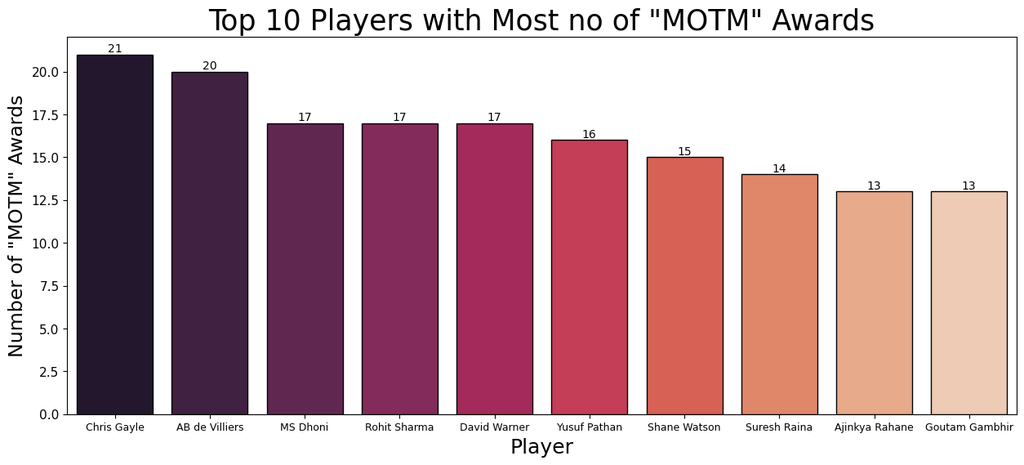

```python
plt.figure(figsize=(15,6))
plt.title('Top 10 Players with Most no of "MOTM" Awards', color='black', fontsize=25)
plt.xticks(fontsize=9)
plt.yticks(fontsize=11)
plt.xlabel('', fontsize=18)
plt.ylabel('', fontsize=17)
Graph_Data={'Player': Man_of_the_Match.index[:10],
            'Awards': Man_of_the_Match.values[:10]}
Bar_Graph=pd.DataFrame(Graph_Data)
Graph = sns.barplot(x='Player', y='Awards', hue='Player', data=Bar_Graph, palette='rocket', edgecolor='black', dodge=False)
Graph.set(ylabel='Number of "MOTM" Awards',xlabel='Player')
for container in Graph.containers:
    Graph.bar_label(container, fontsize=10) # To get LABEL on EACH BAR.
plt.show()
```

2. To get the Frequency of Result Column.

```python
Data['Result'].value_counts()
```

```
Result
Normal    747
Tie         9
Name: count, dtype: int64
```

3. To get the List of Number of Toss Wins with respect to each Team.

```python
Data['Toss_Winner'].value_counts()
```

```
Toss_Winner
Mumbai Indians                 98
Kolkata Knight Riders          92
Chennai Super Kings            89
Royal Challengers Bangalore    81
Kings XI Punjab                81
Delhi Daredevils               80
Rajasthan Royals               80
Sunrisers Hyderabad            46
Deccan Chargers                43
Pune Warriors                  20
Gujarat Lions                  15
Delhi Capitals                 10
Kochi Tuskers Kerala            8
Rising Pune Supergiants         7
Rising Pune Supergiant          6
Name: count, dtype: int64
```

4)(i) To get the List of all the Teams who BATTED FIRST and WON THE MATCH irrespective to the Toss Wins.

```python
Batting_First=Data[(Data['Win_by_Runs'] != 0)].sort_values(by='Win_by_Runs', ascending=False)
Batting_First
```

|  | ID NO | Season | City | Date | Team 1 | Team 2 | Toss_Winner | Toss_Decision | Result | DL_Applied | Winner | Win_by_Runs | Win_by_Wickets | Player_of_Match | Venue | Umpire 1 | Umpire 2 | Umpire 3 |
| --- | --- | --- | --- | --- | --- | --- | --- | --- | --- | --- | --- | --- | --- | --- | --- | --- | --- | --- |
| 43 | 44 | 2017 | Delhi | 5/6/2017 | Mumbai Indians | Delhi Daredevils | Delhi Daredevils | To Field | Normal | 0 | Mumbai Indians | 146 | 0 | LMP Simmons | Feroz Shah Kotla | Nitin Menon | CK Nandan | Not Avaliable |
| 619 | 620 | 2016 | Bangalore | 5/14/2016 | Royal Challengers Bangalore | Gujarat Lions | Gujarat Lions | To Field | Normal | 0 | Royal Challengers Bangalore | 144 | 0 | AB de Villiers | M Chinnaswamy Stadium | AY Dandekar | VK Sharma | Not Avaliable |
| 59 | 60 | 2008 | Bangalore | 4/18/2008 | Kolkata Knight Riders | Royal Challengers Bangalore | Royal Challengers Bangalore | To Field | Normal | 0 | Kolkata Knight Riders | 140 | 0 | BB McCullum | M Chinnaswamy Stadium | Asad Rauf | RE Koertzen | Not Avaliable |
| 556 | 557 | 2015 | Bangalore | 5/6/2015 | Royal Challengers Bangalore | Kings XI Punjab | Kings XI Punjab | To Field | Normal | 0 | Royal Challengers Bangalore | 138 | 0 | Chris Gayle | M Chinnaswamy Stadium | RK Illingworth | VA Kulkarni | Not Avaliable |
| 410 | 411 | 2013 | Bangalore | 4/23/2013 | Royal Challengers Bangalore | Pune Warriors | Pune Warriors | To Field | Normal | 0 | Royal Challengers Bangalore | 130 | 0 | Chris Gayle | M Chinnaswamy Stadium | Aleem Dar | C Shamshuddin | Not Avaliable |
| ... | ... | ... | ... | ... | ... | ... | ... | ... | ... | ... | ... | ... | ... | ... | ... | ... | ... | ... |
| 58 | 59 | 2017 | Hyderabad | 5/21/2017 | Mumbai Indians | Rising Pune Supergiant | Mumbai Indians | To Bat | Normal | 0 | Mumbai Indians | 1 | 0 | KH Pandya | Rajiv Gandhi International Stadium, Uppal | NJ Llong | S Ravi | Not Avaliable |
| 614 | 615 | 2016 | Chandigarh | 5/9/2016 | Royal Challengers Bangalore | Kings XI Punjab | Kings XI Punjab | To Field | Normal | 0 | Royal Challengers Bangalore | 1 | 0 | Shane Watson | Punjab Cricket Association IS Bindra Stadium, ... | AK Chaudhary | HDPK Dharmasena | Not Avaliable |
| 598 | 599 | 2016 | Delhi | 4/27/2016 | Gujarat Lions | Delhi Daredevils | Delhi Daredevils | To Field | Normal | 0 | Gujarat Lions | 1 | 0 | CH Morris | Feroz Shah Kotla | M Erasmus | S Ravi | Not Avaliable |
| 163 | 164 | 2009 | Johannesburg | 5/17/2009 | Kings XI Punjab | Deccan Chargers | Deccan Chargers | To Field | Normal | 0 | Kings XI Punjab | 1 | 0 | Yuvraj Singh | New Wanderers Stadium | S Ravi | RB Tiffin | Not Avaliable |
| 755 | 11415 | 2019 | Hyderabad | 12/5/2019 | Mumbai Indians | Chennai Super Kings | Mumbai Indians | To Bat | Normal | 0 | Mumbai Indians | 1 | 0 | JJ Bumrah | Rajiv Gandhi Intl. Cricket Stadium | Nitin Menon | Ian Gould | Nigel Llong |

337 rows × 18 columns

4)(ii) To get Top 10 Teams.

```python
Batting_First.head(10)
```

|  | ID NO | Season | City | Date | Team 1 | Team 2 | Toss_Winner | Toss_Decision | Result | DL_Applied | Winner | Win_by_Runs | Win_by_Wickets | Player_of_Match | Venue | Umpire 1 | Umpire 2 | Umpire 3 |
| --- | --- | --- | --- | --- | --- | --- | --- | --- | --- | --- | --- | --- | --- | --- | --- | --- | --- | --- |
| 43 | 44 | 2017 | Delhi | 5/6/2017 | Mumbai Indians | Delhi Daredevils | Delhi Daredevils | To Field | Normal | 0 | Mumbai Indians | 146 | 0 | LMP Simmons | Feroz Shah Kotla | Nitin Menon | CK Nandan | Not Avaliable |
| 619 | 620 | 2016 | Bangalore | 5/14/2016 | Royal Challengers Bangalore | Gujarat Lions | Gujarat Lions | To Field | Normal | 0 | Royal Challengers Bangalore | 144 | 0 | AB de Villiers | M Chinnaswamy Stadium | AY Dandekar | VK Sharma | Not Avaliable |
| 59 | 60 | 2008 | Bangalore | 4/18/2008 | Kolkata Knight Riders | Royal Challengers Bangalore | Royal Challengers Bangalore | To Field | Normal | 0 | Kolkata Knight Riders | 140 | 0 | BB McCullum | M Chinnaswamy Stadium | Asad Rauf | RE Koertzen | Not Avaliable |
| 556 | 557 | 2015 | Bangalore | 5/6/2015 | Royal Challengers Bangalore | Kings XI Punjab | Kings XI Punjab | To Field | Normal | 0 | Royal Challengers Bangalore | 138 | 0 | Chris Gayle | M Chinnaswamy Stadium | RK Illingworth | VA Kulkarni | Not Avaliable |
| 410 | 411 | 2013 | Bangalore | 4/23/2013 | Royal Challengers Bangalore | Pune Warriors | Pune Warriors | To Field | Normal | 0 | Royal Challengers Bangalore | 130 | 0 | Chris Gayle | M Chinnaswamy Stadium | Aleem Dar | C Shamshuddin | Not Avaliable |
| 706 | 11147 | 2019 | Hyderabad | 31/03/19 | Sunrisers Hyderabad | Royal Challengers Bangalore | Royal Challengers Bangalore | To Field | Normal | 0 | Sunrisers Hyderabad | 118 | 0 | J Bairstow | Rajiv Gandhi Intl. Cricket Stadium | S Ravi | KN Anantapadmanabhan | C Shamshuddin |
| 295 | 296 | 2011 | Dharamsala | 5/17/2011 | Kings XI Punjab | Royal Challengers Bangalore | Kings XI Punjab | To Bat | Normal | 0 | Kings XI Punjab | 111 | 0 | AC Gilchrist | Himachal Pradesh Cricket Association Stadium | Asad Rauf | AM Saheba | Not Avaliable |
| 114 | 115 | 2008 | Mumbai | 5/30/2008 | Rajasthan Royals | Delhi Daredevils | Delhi Daredevils | To Field | Normal | 0 | Rajasthan Royals | 105 | 0 | Shane Watson | Wankhede Stadium | BF Bowden | RE Koertzen | Not Avaliable |
| 676 | 7934 | 2018 | Kolkata | 9/5/2018 | Mumbai Indians | Kolkata Knight Riders | Kolkata Knight Riders | To Field | Normal | 0 | Mumbai Indians | 102 | 0 | Ishan Kishan | Eden Gardens | Anil Chaudhary | K Ananthapadmanabhan | Kumar Dharmasena |
| 182 | 183 | 2010 | Delhi | 3/17/2010 | Mumbai Indians | Delhi Daredevils | Delhi Daredevils | To Field | Normal | 0 | Mumbai Indians | 98 | 0 | SR Tendulkar | Feroz Shah Kotla | BR Doctrove | SK Tarapore | Not Avaliable |

5)(i) To get the List of Number of Wins with respect to Each Team after BATTING FIRST.

```python
Batting_First['Winner'].value_counts()
```

```
Winner
Mumbai Indians                 57
Chennai Super Kings            52
Kings XI Punjab                38
Kolkata Knight Riders          36
Royal Challengers Bangalore    35
Sunrisers Hyderabad            30
Rajasthan Royals               27
Delhi Daredevils               25
Deccan Chargers                18
Pune Warriors                   6
Rising Pune Supergiant          5
Delhi Capitals                  3
Rising Pune Supergiants         2
Kochi Tuskers Kerala            2
Gujarat Lions                   1
Name: count, dtype: int64
```

5)(ii) To Plot the Graph.

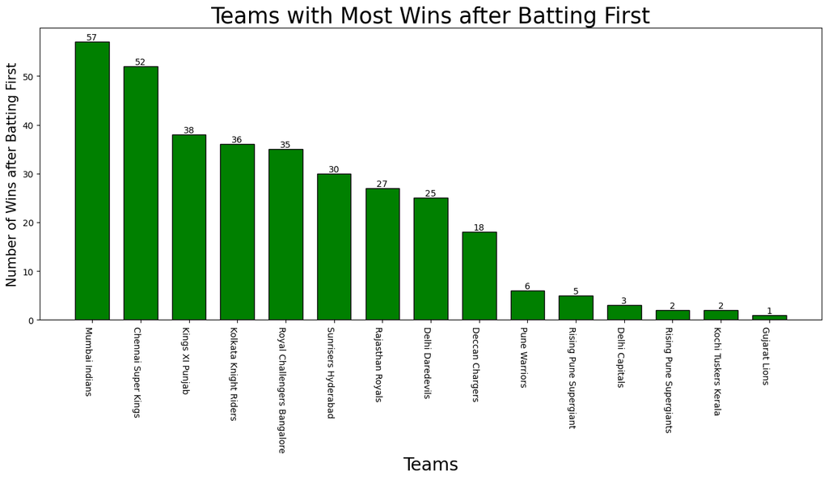

```python
Batting_First_Plot=list(Batting_First['Winner'].value_counts().keys())
Counts=list(Batting_First['Winner'].value_counts())
plt.figure(figsize=(16,6))
Bars=plt.bar(Batting_First_Plot,Counts,width=0.7,edgecolor='black',color='green')
for bar in Bars: plt.text(bar.get_x() + bar.get_width() / 2, # This puts the text in the MIDDLE of the BAR Horizontally.
                          bar.get_height(), # This places the text at the TOP Edge of the BAR.
                          f'{bar.get_height()}',  # This shows the HEIGHT of the BAR as the Text.
                          ha='center', # This CENTERS the TEXT Horizontally.
                          va='bottom', # This ALIGNS the TEXT just ABOVE the Top Edge of the Bar.
                          fontsize=10)
plt.xticks(rotation=270,fontsize=10,ha='right')
plt.yticks(fontsize=10)
plt.xlabel('Teams',fontsize=20)
plt.ylabel('Number of Wins after Batting First',fontsize=15)
plt.title('Teams with Most Wins after Batting First',color='black',fontsize=25)
plt.show()
```

5)(iii) To Plot a Pie Chart.

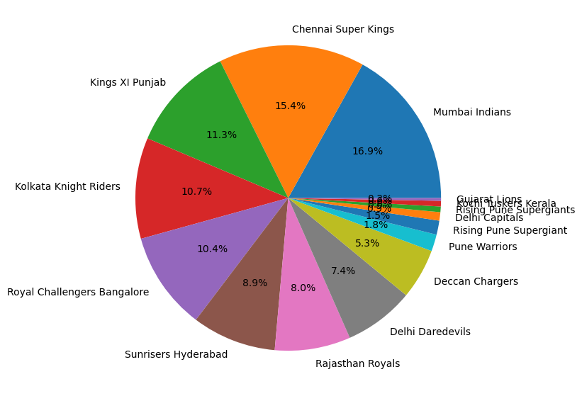

```python
plt.figure(figsize=(7,7))
plt.pie(Counts,labels=Batting_First_Plot,autopct='%0.1f%%')
plt.show()
```

6)(i) To get the List of all the Teams who BATTED SECOND and WON THE MATCH irrespective to the Toss Wins.

```python
Batting_Second=Data[(Data['Win_by_Wickets'] != 0)].sort_values(by='Win_by_Wickets', ascending=False)
Batting_Second
```

|  | ID NO | Season | City | Date | Team 1 | Team 2 | Toss_Winner | Toss_Decision | Result | DL_Applied | Winner | Win_by_Runs | Win_by_Wickets | Player_of_Match | Venue | Umpire 1 | Umpire 2 | Umpire 3 |
| --- | --- | --- | --- | --- | --- | --- | --- | --- | --- | --- | --- | --- | --- | --- | --- | --- | --- | --- |
| 376 | 377 | 2012 | Jaipur | 5/20/2012 | Rajasthan Royals | Mumbai Indians | Rajasthan Royals | To Bat | Normal | 0 | Mumbai Indians | 0 | 10 | DR Smith | Sawai Mansingh Stadium | HDPK Dharmasena | C Shamshuddin | Not Avaliable |
| 683 | 7941 | 2018 | Indore | 14/05/18 | Kings XI Punjab | Royal Challengers Bangalore | Royal Challengers Bangalore | To Field | Normal | 0 | Royal Challengers Bangalore | 0 | 10 | UT Yadav | Holkar Cricket Stadium | Bruce Oxenford | Virender Kumar Sharma | O Nandan |
| 390 | 391 | 2013 | Chandigarh | 4/10/2013 | Kings XI Punjab | Chennai Super Kings | Chennai Super Kings | To Field | Normal | 0 | Chennai Super Kings | 0 | 10 | MEK Hussey | Punjab Cricket Association Stadium, Mohali | Aleem Dar | C Shamshuddin | Not Avaliable |
| 590 | 591 | 2016 | Rajkot | 4/21/2016 | Gujarat Lions | Sunrisers Hyderabad | Sunrisers Hyderabad | To Field | Normal | 0 | Sunrisers Hyderabad | 0 | 10 | B Kumar | Saurashtra Cricket Association Stadium | K Bharatan | HDPK Dharmasena | Not Avaliable |
| 183 | 184 | 2010 | Bangalore | 3/18/2010 | Rajasthan Royals | Royal Challengers Bangalore | Royal Challengers Bangalore | To Field | Normal | 0 | Royal Challengers Bangalore | 0 | 10 | JH Kallis | M Chinnaswamy Stadium | K Hariharan | DJ Harper | Not Avaliable |
| ... | ... | ... | ... | ... | ... | ... | ... | ... | ... | ... | ... | ... | ... | ... | ... | ... | ... | ... |
| 48 | 49 | 2017 | Kanpur | 5/10/2017 | Gujarat Lions | Delhi Daredevils | Delhi Daredevils | To Field | Normal | 0 | Delhi Daredevils | 0 | 2 | SS Iyer | Green Park | YC Barde | AK Chaudhary | Not Avaliable |
| 753 | 11413 | 2019 | Visakhapatnam | 8/5/2019 | Sunrisers Hyderabad | Delhi Capitals | Delhi Capitals | To Field | Normal | 0 | Delhi Capitals | 0 | 2 | RR Pant | ACA-VDCA Stadium | Not Avaliable | Not Avaliable | Not Avaliable |
| 559 | 560 | 2015 | Kolkata | 5/9/2015 | Kings XI Punjab | Kolkata Knight Riders | Kings XI Punjab | To Bat | Normal | 0 | Kolkata Knight Riders | 0 | 1 | AD Russell | Eden Gardens | AK Chaudhary | HDPK Dharmasena | Not Avaliable |
| 636 | 7894 | 2018 | Mumbai | 7/4/2018 | Mumbai Indians | Chennai Super Kings | Chennai Super Kings | To Field | Normal | 0 | Chennai Super Kings | 0 | 1 | DJ Bravo | Wankhede Stadium | Chris Gaffaney | A Nanda Kishore | Anil Chaudhary |
| 642 | 7900 | 2018 | Hyderabad | 12/4/2018 | Mumbai Indians | Sunrisers Hyderabad | Sunrisers Hyderabad | To Field | Normal | 0 | Sunrisers Hyderabad | 0 | 1 | Rashid Khan | Rajiv Gandhi International Stadium, Uppal | O Nandan | Nigel Llong | Vineet Kulkarni |

406 rows × 18 columns

6)(ii) To get Top 10 Teams.

```python
Batting_Second.head(10)
```

|  | ID NO | Season | City | Date | Team 1 | Team 2 | Toss_Winner | Toss_Decision | Result | DL_Applied | Winner | Win_by_Runs | Win_by_Wickets | Player_of_Match | Venue | Umpire 1 | Umpire 2 | Umpire 3 |
| --- | --- | --- | --- | --- | --- | --- | --- | --- | --- | --- | --- | --- | --- | --- | --- | --- | --- | --- |
| 376 | 377 | 2012 | Jaipur | 5/20/2012 | Rajasthan Royals | Mumbai Indians | Rajasthan Royals | To Bat | Normal | 0 | Mumbai Indians | 0 | 10 | DR Smith | Sawai Mansingh Stadium | HDPK Dharmasena | C Shamshuddin | Not Avaliable |
| 683 | 7941 | 2018 | Indore | 14/05/18 | Kings XI Punjab | Royal Challengers Bangalore | Royal Challengers Bangalore | To Field | Normal | 0 | Royal Challengers Bangalore | 0 | 10 | UT Yadav | Holkar Cricket Stadium | Bruce Oxenford | Virender Kumar Sharma | O Nandan |
| 390 | 391 | 2013 | Chandigarh | 4/10/2013 | Kings XI Punjab | Chennai Super Kings | Chennai Super Kings | To Field | Normal | 0 | Chennai Super Kings | 0 | 10 | MEK Hussey | Punjab Cricket Association Stadium, Mohali | Aleem Dar | C Shamshuddin | Not Avaliable |
| 590 | 591 | 2016 | Rajkot | 4/21/2016 | Gujarat Lions | Sunrisers Hyderabad | Sunrisers Hyderabad | To Field | Normal | 0 | Sunrisers Hyderabad | 0 | 10 | B Kumar | Saurashtra Cricket Association Stadium | K Bharatan | HDPK Dharmasena | Not Avaliable |
| 183 | 184 | 2010 | Bangalore | 3/18/2010 | Rajasthan Royals | Royal Challengers Bangalore | Royal Challengers Bangalore | To Field | Normal | 0 | Royal Challengers Bangalore | 0 | 10 | JH Kallis | M Chinnaswamy Stadium | K Hariharan | DJ Harper | Not Avaliable |
| 2 | 3 | 2017 | Rajkot | 4/7/2017 | Gujarat Lions | Kolkata Knight Riders | Kolkata Knight Riders | To Field | Normal | 0 | Kolkata Knight Riders | 0 | 10 | CA Lynn | Saurashtra Cricket Association Stadium | Nitin Menon | CK Nandan | Not Avaliable |
| 542 | 543 | 2015 | Delhi | 4/26/2015 | Delhi Daredevils | Royal Challengers Bangalore | Royal Challengers Bangalore | To Field | Normal | 0 | Royal Challengers Bangalore | 0 | 10 | VR Aaron | Feroz Shah Kotla | M Erasmus | S Ravi | Not Avaliable |
| 34 | 35 | 2017 | Chandigarh | 4/30/2017 | Delhi Daredevils | Kings XI Punjab | Kings XI Punjab | To Field | Normal | 0 | Kings XI Punjab | 0 | 10 | Sandeep Sharma | Punjab Cricket Association IS Bindra Stadium, ... | YC Barde | CK Nandan | Not Avaliable |
| 119 | 120 | 2009 | Cape Town | 4/19/2009 | Kings XI Punjab | Delhi Daredevils | Delhi Daredevils | To Field | Normal | 1 | Delhi Daredevils | 0 | 10 | DL Vettori | Newlands | MR Benson | SD Ranade | Not Avaliable |
| 298 | 299 | 2011 | Mumbai | 5/20/2011 | Mumbai Indians | Rajasthan Royals | Mumbai Indians | To Bat | Normal | 0 | Rajasthan Royals | 0 | 10 | Shane Watson | Wankhede Stadium | RE Koertzen | PR Reiffel | Not Avaliable |

7)(i) To get the List of Number of Wins with respect to Each Team after BATTING SECOND.

```python
Batting_Second['Winner'].value_counts()
```

```
Winner
Kolkata Knight Riders          56
Mumbai Indians                 50
Royal Challengers Bangalore    48
Chennai Super Kings            48
Rajasthan Royals               46
Kings XI Punjab                42
Delhi Daredevils               42
Sunrisers Hyderabad            27
Gujarat Lions                  12
Deccan Chargers                11
Delhi Capitals                  6
Pune Warriors                   6
Rising Pune Supergiant          5
Kochi Tuskers Kerala            4
Rising Pune Supergiants         3
Name: count, dtype: int64
```

7)(ii) To Plot the Graph.

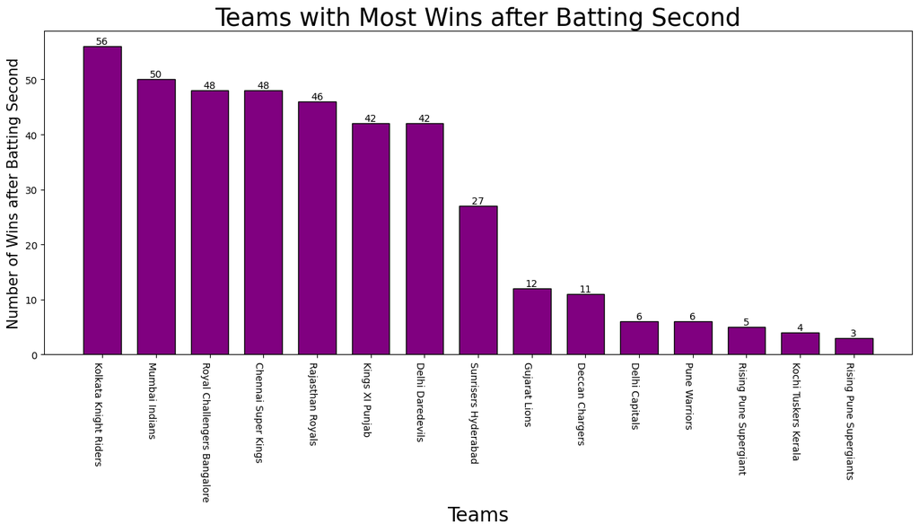

```python
Batting_Second_Plot=list(Batting_Second['Winner'].value_counts().keys())
Counts=list(Batting_Second['Winner'].value_counts())
plt.figure(figsize=(16,6))
Bars=plt.bar(Batting_Second_Plot,Counts,width=0.7,edgecolor='black',color='purple')
for bar in Bars: plt.text(bar.get_x() + bar.get_width() / 2, # This puts the text in the MIDDLE of the BAR Horizontally.
                          bar.get_height(), # This places the text at the TOP Edge of the BAR.
                          f'{bar.get_height()}',  # This shows the HEIGHT of the BAR as the Text.
                          ha='center', # This CENTERS the TEXT Horizontally.
                          va='bottom', # This ALIGNS the TEXT just ABOVE the Top Edge of the Bar.
                          fontsize=10)
plt.xticks(rotation=270,fontsize=10,ha='right')
plt.yticks(fontsize=10)
plt.xlabel('Teams',fontsize=20)
plt.ylabel('Number of Wins after Batting Second',fontsize=15)
plt.title('Teams with Most Wins after Batting Second',color='black',fontsize=25)
plt.show()
```

7)(iii) To Plot a Pie Chart.

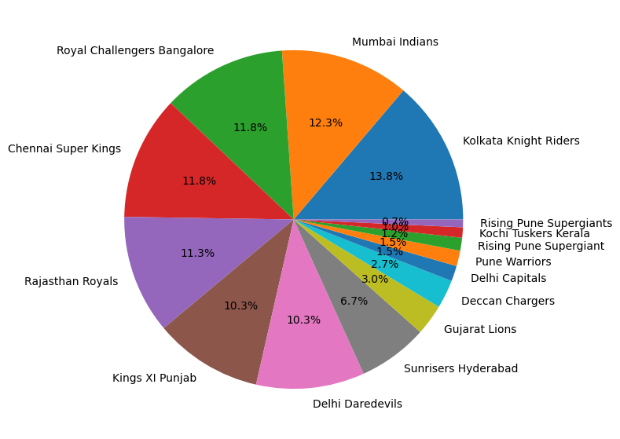

```python
plt.figure(figsize=(7,7))
plt.pie(Counts,labels=Batting_Second_Plot,autopct='%0.1f%%')
plt.show()
```

8. To get the List of Number of Matches played in Each Season.

```python
Data['Season'].value_counts()
```

```
Season
2013    76
2012    74
2011    73
2010    60
2014    60
2016    60
2018    60
2019    60
2017    59
2015    59
2008    58
2009    57
Name: count, dtype: int64
```

9. To get the List of Number of Matches played in Each City.

```python
Data['City'].value_counts()
```

```
City
Mumbai            102
Kolkata            78
Delhi              75
Bangalore          67
Hyderabad          65
Chennai            58
Jaipur             47
Chandigarh         46
Pune               38
Durban             15
Bengaluru          14
Visakhapatnam      13
Centurion          12
Ahmedabad          12
Rajkot             10
Mohali             10
Indore              9
Dharamsala          9
Johannesburg        8
Ranchi              7
Port Elizabeth      7
Abu Dhabi           7
Cuttack             7
Cape Town           7
Raipur              6
Sharjah             6
Kochi               5
Kanpur              4
Nagpur              3
Kimberley           3
East London         3
Bloemfontein        2
Rajasthan           1
Name: count, dtype: int64
```

10)(i) To find How many Times a Team has Won the Match after Winning the Toss.

```python
np.sum(Data['Toss_Winner']==Data['Winner'])
```

```
396
```

10)(ii) To get the Percentage.

```python
(396/756)*100
```

```
52.38095238095239
```